# 565hw1

## 1 Description

### Course STAT565 Decision Theory and Bayesian Analysis

#### Semester Fall 2017

#### Content Assignment 1: Visualizing Bivariate Data

#### Author Enes Dilber

```r
#loading required libraries
library(mvtnorm)
library(ggplot2)
library(plotly)
library(plot3D)
```

## 2 Visualizing Contionous Bivariate Distribution

### 2.1 Empirical Data

#### 2.1.1 Random Sample from Bivariate Normal Distribution

$$Let \ X \sim N_2 \biggl(\mu = \left[ {\begin{array}{c} 0\\ 0\\ \end{array} } \right],\Sigma = \left[ {\begin{array}{cc} 9 & \sigma_{12} \\ \sigma_{21} & 4 \\ \end{array} } \right] \biggl) $$

We are going to select three random samples(say S<sub>1</sub>, S<sub>2</sub>, S<sub>3</sub>) size n from X with correlation 0, 0.5 and 9 and discuss their shapes, how it affected by correlation coefficient.  
We know;

$$ \sigma_{12} = \sigma_{21} = \rho_{12}\sqrt{\sigma_{22}\sigma_{11}} $$

for S<sub>1</sub>; $$ \sigma_{12} = \sigma_{21} = 0 \times \sqrt{9 \times 4 } = 0$$

for S<sub>2</sub>; $$ \sigma_{12} = \sigma_{21} = 0.5 \times \sqrt{9 \times 4 } = 3$$

for S<sub>3</sub>; $$ \sigma_{12} = \sigma_{21} = 0.9 \times \sqrt{9 \times 4 } = 5.4$$

```r
sample_BVN = function(n, M, V, seed = 108){

  # n = (scaler int) sample size
  # M = (size 2 vector) mean vector
  # V = (size 2 vector) variance vector

  function(correlation){

    # correlation  = (scaler float) desired correlation coefficient

    set.seed(seed)

    M = matrix(M, 2, 1)
    S = matrix(c(V[1], correlation*sqrt(V[1]*V[2]), correlation*sqrt(V[1]*V[2]), V[2]), 2, 2)

    X = rmvnorm(n, M, S)
    z = apply(X, 1, function(x) dmvnorm(x, M, S))

    return(cbind(X,z))
  }
}

M = c(0, 0)
V = c(9, 4)
n = 1000

#Using closure feature of R, we create sample_BVNX function with predefined n, M and V. It only needs correlation input:
sample_BVNX = sample_BVN(n, M, V)
```

#### 2.1.2 Scatter Plot with Color

```r
SP_withcolor = function(data){

  # data = (n x 3 matrix) sampled bivariate normal data and their density value

  data = data.frame(data)
  colnames(data) = c("x1", "x2", "density")

  ggplot(data, aes(x=x1, y=x2, color=density)) +
    scale_colour_gradient(low = "white", high = "black")+
    geom_point() + coord_fixed()
}
```

Apply 3 different correlation value to sampling function and draw their Bubble Chart:

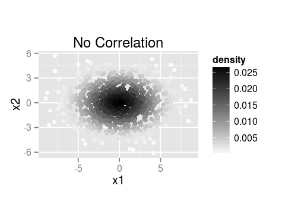

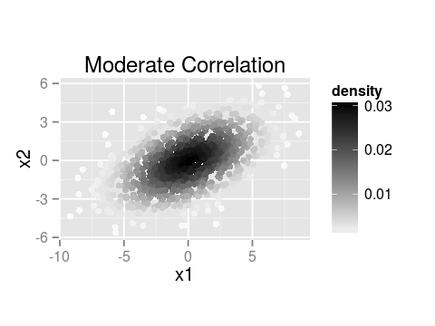

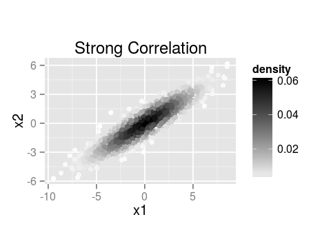

```r
SP_withcolor(sample_BVNX(0)) + ggtitle("No Correlation")
SP_withcolor(sample_BVNX(0.5)) + ggtitle("Moderate Correlation")
SP_withcolor(sample_BVNX(0.9)) + ggtitle("Strong Correlation")
```

#### 2.1.3 Contour Plot with Histograms

```r
contour_histogram = function(data){

  # data = (n x 3 matrix) sampled bivariate normal data and their density value

  x1 = data[,1]
  x2 = data[,2]
  s <- subplot(
    plot_ly(x = x1, type = "histogram"),
    plotly_empty(),
    plot_ly(x = x1, y = x2, type = "histogram2dcontour"),
    plot_ly(y = x2, type = "histogram"),
    nrows = 2, heights = c(0.2, 0.8), widths = c(0.8, 0.2), margin = 0,
    shareX = TRUE, shareY = TRUE, titleX = FALSE, titleY = FALSE
  )
  layout(s, showlegend = FALSE)
}
```

Apply 3 different correlation value to sampling function and draw their Contour Plot with Histogram:

```r
lapply(c(0, 0.5, 0.9), function(c) contour_histogram(sample_BVNX(c)))
```

No Correlation:

[figure not shown]

Moderate Correlation:

[figure not shown]

Strong Correlation:

[figure not shown]

When there is no correlation, contour shape seems elliptic with diameters that are propotional to variances of two marginal distributions. But when covariance increase, shape of contour start to accumulate around the line with a positive slope (since correlation is positive). Same comment applies for scatter plot.

## 2.2 Probability Density Function in 3D

```r
#Bivariate continous Density

plot_mvn = function(M, S, intervalx1, intervalx2){

  # M = (size 2 vector) means of marginals
  # S = (2 x 2 matrix) parameter of first random variable
  # intervalx1 = (size 2 vector) desired x1 interval for plotting
  # intervalx2 = (size 2 vector) desired x2 interval for plotting

  x1 = seq(intervalx1[1], intervalx1[2], length = 100)
  x2 = seq(intervalx2[1], intervalx2[2], length = 100)
  Mu = mesh(x1, x2)

  x = Mu$x
  y = Mu$y

  z = matrix(0, 100, 100)
  for(i in 1:100){
    for(j in 1:100){
      z[i, j] = dmvnorm(x = c(x[i, j], y[i, j]), M, S)
    }
  }

  df = list(x1 = x1, x2 = x2, z=z)

  plot_ly(x = df$x1, y = df$x2, z = df$z) %>% add_surface()
}

M = matrix(c(0, 0), 2, 1)
S = matrix(c(10, 0, 0, 10), 2, 2)

plot_mvn(M, S, c(-10, 10),  c(-10, 10))
```

[figure not shown]

If we repeat the process for a variaty of covariances, we are going to get similar results with part 2.1

## 3 Visualizing Discrete Bivariate Distribution

### 3.1 Bivariate Poisson Probability Mass Function

```r
dBVP = function(x, theta1, theta2, theta0){

  # x = (size 2 vector) x1 and x2 values
  # theta1 = (scaler) parameter of first random variable
  # theta2 = (scaler) parameter of second random variable
  # theta0 = (scaler) parameter of covariance of random variable

  u = x[1]
  v = x[2]

  a = exp(-(theta1+theta2+theta0))
  b = ((theta1^u)*(theta2^v))/(factorial(u)*factorial(v))

  c = 0
  i_from = 0
  i_to = min(u,v)
  for(i in i_from:i_to){
    c1 = dim(combn(u,i))[2]*dim(combn(v,i))[2]
    c2 = factorial(i)*((theta0/(theta1*theta2))^i)
    c = c + c1*c2
  }

  indicator = (theta1 > theta0)*(theta2 > theta0)*(theta0 > 0)

  return(a*b*c*indicator)

}
```

```r
BVP_data = function(theta1, theta2, intervalx1, intervalx2){

  # theta1 = (scaler) parameter of first random variable
  # theta2 = (scaler) parameter of second random variable
  # intervalx1 = (size n integer vector) desired x1 interval for plotting
  # intervalx2 = (size n integer vector) desired x2 interval for plotting

  function(correlation){

  # correlation  = (scaler float) desired correlation coefficient

    theta0 = correlation*sqrt(theta1*theta2)

    bvpdat = expand.grid(intervalx1, intervalx2)
    bvpdat = data.frame(bvpdat)
    colnames(bvpdat) = c("x1", "x2")
    bvpdat$density = apply(bvpdat, 1, function(x) dBVP(x, theta1, theta2, theta0))

    return(bvpdat)
  }
}

theta1 = 4
theta2 = 4
intervalx1 = intervalx2 = 0:15

BVP_dataX0 = BVP_data(theta1, theta2, intervalx1, intervalx2)
```

### 3.2 Heatmap

```r
plot_BVP = function(data){

  # data = (n x 3 matrix) sampled bivariate normal data and their density value

  ggplot(data, aes(x = x1, y = x2)) +
    geom_tile(aes(fill = density), width=0.90, height=0.90) +
    scale_fill_gradient(low = "white", high = "black")+
    scale_x_continuous(breaks=seq(0, 15, 1))+scale_y_continuous(breaks=seq(0, 15, 1))+
    coord_fixed() + theme(panel.grid.major = element_blank(), panel.grid.minor = element_blank())
}
```

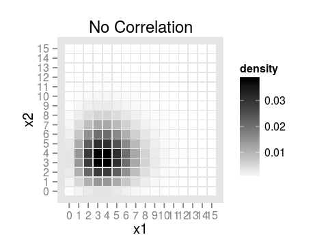

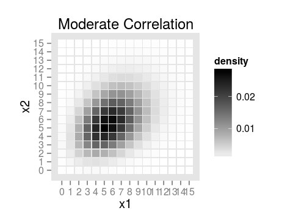

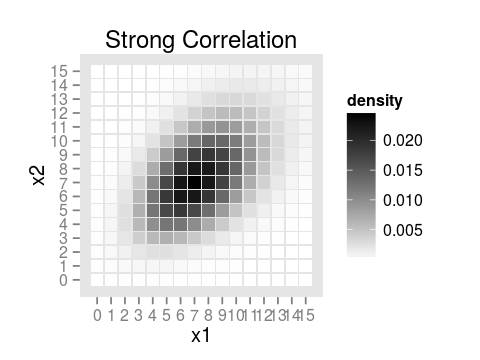

```r
plot_BVP(BVP_dataX0(1e-10)) + ggtitle("No Correlation")
plot_BVP(BVP_dataX0(0.5)) + ggtitle("Moderate Correlation")
plot_BVP(BVP_dataX0(0.9)) + ggtitle("Strong Correlation")
```

We got similar results with continous cases(It is quite similar to contour). The only difference is, when we increase covariance parameter, mean of both marginals also increased. This is the characteristic of Poisson distribution. In Normal Distribution, mean and variances are independent. They have their own, independent parameters. However, it dependes same parameters in Poissson. Spesifically, in bivariate poisson marginal distributions are as follows;

$$ X_1 \sim Poisson(\theta_1+\theta_0) \\ X_2 \sim Poisson(\theta_2+\theta_0) $$

As a result, not only the shape of distribution changes, location also shifts.